# Question

A taught string, fixed at 2 ends, produces a harmonic series based on the [standing waves](https://en.wikipedia.org/wiki/Standing_wave#Standing_wave_on_a_string_with_two_fixed_ends) that [resonate](https://en.wikipedia.org/wiki/Resonance). Other frequencies fizzle out quickly because they are not resonant with the system.

We will simulate a string vibrating at its [fundamental frequency](https://en.wikipedia.org/wiki/Fundamental_frequency) and two of its [overtones](https://en.wikipedia.org/wiki/Overtone). We will also pay attention to the phase of each partial.

Let’s assume the string is of length $\pi$ meters and the period of the fundamental is $2\pi$ seconds (so $t$ goes from 0 to $2\pi$).

$$y_1 = A_1 \sin(x)\cdot
\sin(t+\phi_1)$$

The next two overtones have similar equations.

$$y_2 = A_2 \sin(2x)\cdot
\sin(2t+\phi_2)$$

$$y_3 = A_3 \sin(3x)\cdot
\sin(3t+\phi_3)$$

When all three modes of oscillation occur simultaneously, the result is a superposition of waves.

$$y = y_1+y_2+y_3$$

Determine which set of parameters generates the animation below (when viewing the superposition).

### Parameter set 1

$$\begin{align*}
A_1 &= 0.1 & \phi_1 &= 5.6 \\
A_2 &= 0.84 & \phi_2 &= 2.94 \\
A_3 &= 0.06 & \phi_3 &= 3.82 \\
\end{align*}$$

### Parameter set 2

$$\begin{align*}
A_1 &= 0.11 & \phi_1 &= 6.11 \\
A_2 &= 0.44 & \phi_2 &= 2.64 \\
A_3 &= 0.45 & \phi_3 &= 5.41 \\
\end{align*}$$

### Parameter set 3

$$\begin{align*}
A_1 &= 0.43 & \phi_1 &= 1.13 \\
A_2 &= 0.48 & \phi_2 &= 2.22 \\
A_3 &= 0.09 & \phi_3 &= 5.93 \\
\end{align*}$$

### Parameter set 4

$$\begin{align*}
A_1 &= 0.12 & \phi_1 &= 0.74 \\
A_2 &= 0.13 & \phi_2 &= 1.19 \\
A_3 &= 0.75 & \phi_3 &= 0.62 \\
\end{align*}$$

### Parameter set 5

$$\begin{align*}
A_1 &= 0.79 & \phi_1 &= 6.02 \\
A_2 &= 0.14 & \phi_2 &= 1.5 \\
A_3 &= 0.07 & \phi_3 &= 4.66 \\
\end{align*}$$

### Parameter set 6

$$\begin{align*}
A_1 &= 0.42 & \phi_1 &= 0.39 \\
A_2 &= 0.12 & \phi_2 &= 4.94 \\
A_3 &= 0.46 & \phi_3 &= 2.35 \\
\end{align*}$$

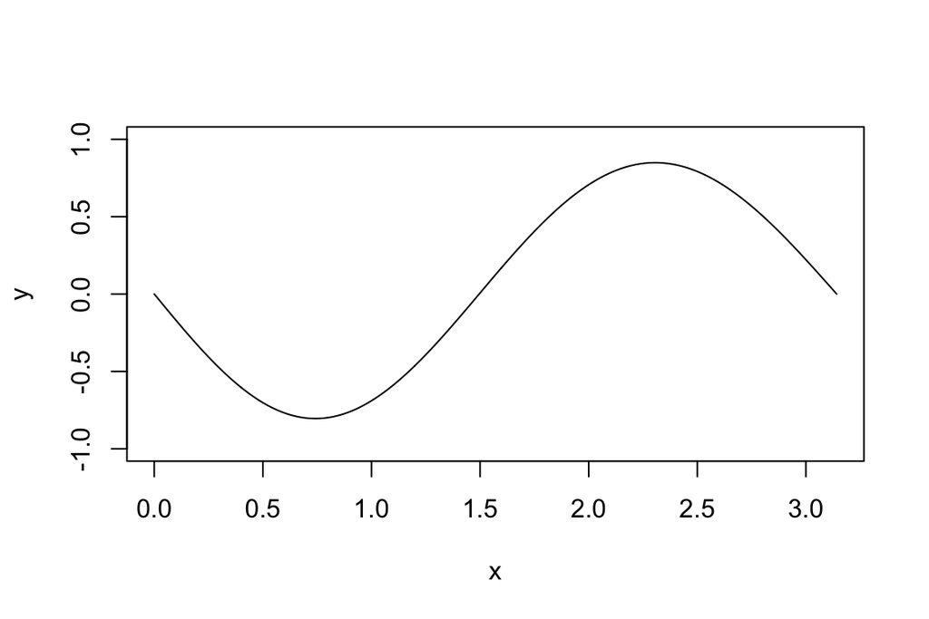

## Answerlist

- Parameter set 1
- Parameter set 2
- Parameter set 3
- Parameter set 4
- Parameter set 5
- Parameter set 6

# Solution

Write each equation in Desmos, adding sliders as suggested. Set the sliders to the given values and see if the animations match. Hide the individual partials and only show the superposition.

You can restrict the domain by ending each equations with $\{0\le x\le \pi\}$.

$y=y_1+y_2+y_3$

The last equation (the summation of the partials) is the superposition whose animation you want to view.

### The correct parameter set is set 1:

$$\begin{align*}
A_1 &= 0.1 & \phi_1 &= 5.6 \\
A_2 &= 0.84 & \phi_2 &= 2.94 \\
A_3 &= 0.06 & \phi_3 &= 3.82 \\
\end{align*}$$

# Meta-information

extype: schoice exsolution: 100000 exname: string_animation